# Week 2 Notes Part 1 Probability Distributions and Sampling

# 1 Overview

In this Note random variables are introduced more formally. Then we discuss probability distribution functions, Bernoulli and binomial random variables, and conclude by reviewing some aspects of the support provided in R for numerical simulations and working with various distributions.

# 2 Random Variables

The notion of variable in probability and statistics is different from other domains. Indeed, we are accustomed to thinking of a mathematical variable as representing a possibly unknown (yet) but single, fixed value. For instance, a variable in an equation represents some value that we can solve the equation for (at least conceptually; the fact that we may not have analytical or even numerical capability to solve a particular equation or a system of equations does not matter in this context).

In contrast, in probability theory and statistics randomness is always involved (if it is not, then there is no need to apply probability and statistics in the first place!). Subsequent measurements of the “same” quantity may and will give different results, with variation due to chance. Such quantities are referred to as random variables. One can think of random variable as some (random) process that can generate subsequent measurements, should we decide to take them. A conventional albeit not exclusive notation is to use capital letters to represent a random variable (process), e.g. `X`, and small letters to represent particular value(s) that the random variable may take (or may have taken when we measured it), e.g. `x1, x2, ...` These values are also referred sometimes as a particular realization (i.e. a random variable may take a range of values, by chance – those are the possibilities; the values that random variable did take when we measured it were actually realized). It is also common in the literature to represent a sentence “random variable `X` took particular value x” using notation `X=x` (this is not an equation or equality!).

It is important that the nature of the randomness is completely irrelevant: the theory deals with processes that can be described in a probabilistic framework, whether the process is “objectively” random or the randomness is “subjective” and due to incomplete knowledge. The meaning of probabilities assigned to different realizations of a random variable is not part of the probability theory! In some cases the question of how exactly the randomness is introduced and interpreted is still interesting if not important; for instance if we understand the mechanism that generates randomness, we may have a better idea as to how to model the latter. In some others cases this question may be purely philosophical.

Let us consider a few examples.

Suppose we are studying a radioactive sample and using a particle detector to measure the number N of alpha particles emitted during 1 second data acquisition window. Or, in a different experiment, we could use photon detector and measure the number of photons emitted by a laser during 1 second window. In both cases, the number N is a random variable. Fundamental physical laws tell us that a radioactive atom will eventually decay and optically excited atom will eventually emit a photon. However, the same laws tell us that there is no way to know when exactly this is going to happen. Because of that, during one 1-second acquisition window some random, unpredictable number of atoms may decide that “it is time” to decay or emit, and during another window this number can be different (the probabilities associated with different values (counts) $n$ of our random variable $N$ are of course different as well, some counts will be more likely than others). This is an example of truly objective random process; the randomness is introduced by the laws of the Universe itself.

Consider a couple of (seemingly) completely different examples: a number $N$ of phone calls a call center receives in a given minute; or a number of node failures in a large compute farm during a given day. Under certain assumptions, the random variable $N$ has the same properties as in the physical examples above. Namely, as long as we have, e.g. hundreds of thousands of customers in the call center, or thousands of nodes in the compute farm, we can assume that on average each customer has the same small probability to require assistance in any given minute, or any node has small probability of failure during any given day. If this assumption is correct, then the problem is exactly the same (mathematically) as when we have large number of radioactive atoms and each of them has a small probability to decay within any given 1-second window, so our random variables representing numbers of calls and numbers of failures should have the same properties.

Of course, in the last examples we had to make some assumptions in order to build our model. Assumptions are just that, assumptions, and they can be correct, reasonable (for a specific goal) or outright wrong. It is an important application of the statistical techniques and approaches to try answering the question whether the observed data fits the assumptions we make about them. For instance we could ask whether the per-minute call rate during 5pm-7pm window differs significantly from the call rate between 9am and noon, or all the observed differences are actually within the expected minute-to-minute fluctuations.

It would be also a shame not to mention a “classical” example of a random variable: the result of a coin toss. This discrete random variable can take only two values: `H(ead)` and `T(ail)`.

A little more interesting example is provided, for instance, by gene expression. Suppose our “random variable” $X$ is the expression of some gene in a patient. What is random here? In what context we can apply statistical analysis? Apparently, if we measure expression of our gene in different patients we will be getting different values, and with respect to this experiment we may consider $X$ a random variable… But is it random at all? The fact that the measured value is different in different people is not that surprising. If 1) we assume a mechanistic model that gene expression is reasonably tightly controlled by cellular machinery, 2) assume for a second that we know all those control mechanisms, 3) also assume that we know exactly full set of internal and environmental conditions a particular patient is exposed to and which serve as inputs to the above control mechanisms… there will be no randomness left. However, since the assumptions above (at least 2 and 3) do not hold, the observations of gene expression across multiple patients will definitely look to us as a random variable because we are missing so much information.

Let us turn to a final example, also very important to us in the context of statistical analysis: suppose we have a population and we are interested in weights. Or blood pressures. Or each person’s votes (Democratic or Republican). If we do know weight, blood pressure, and party affiliation of each and every person in the population there is not much statistical analysis left to do. Granted, we can do some descriptive analysis: it is still interesting, for instance, what the average values are, and what are the spreads (e.g. standard deviation, `IQR`, etc) in the population, or what is the Republican:Democrat ratio . But where is the random component? The answer is that there is none. When everybody votes, all is left is to count ballots. But in most real cases (except maybe for voting itself), we do not and cannot measure the whole population. Instead, we are selecting a sample – 100, 500, or maybe 1000 people, perform measurements on them (or do opinion poll), and then try to generalize to the population. This approach introduces randomness through the sampling process and we need statistics to overcome it: the mean blood pressure in the whole population is not a random variable, it is just a number. However, the mean blood pressure in a cohort of 100 people is a random variable! If we select (randomly!) next cohort, measure blood pressures and compute the mean, it will be slightly different from the previous value. Since the cohort selection is random there is really no way to predict exactly what mean blood pressure next cohort is going to have (or exactly how many Republicans vs Democrats is going to be there etc).

# 3 Probability Distribution

In the previous section we talked about random variables, but we carefully avoided an important topic: different probabilities assigned to different possible values (realizations) of such variable.

Let us consider a random variable `X` representing a toss of a fair coin. The probabilities of observing a head or a tail in a single toss are obviously both equal 0.5 (and the sum of the probabilities of all outcomes is $0.5+0.5=1$, since if we consider all possible outcomes, one of them is bound to happen!). Using the notation introduced in the previous section, we can write this as $P\left ( X=H \right ) = P\left ( X=T \right ) = 0.5$, i.e. “the probability for the random variable X to take the value H upon a measurement is equal to the probability of that variable to take the value T and is equal to 0.5”. Although this particular example is quite trivial, we will draw the probability distribution nonetheless (and also use R to do the drawing for us, watch the commands below, in particular how default numerical axis is suppressed in plot() function and then x-axis with labels is drawn separately):

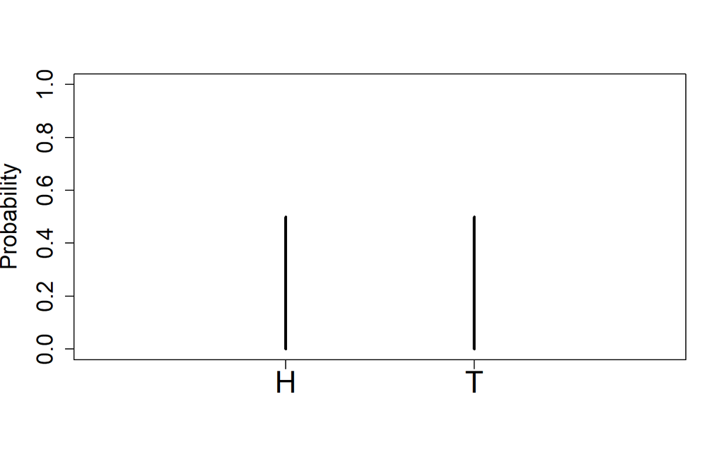

```r
plot(c(0.5,0.5),type='h',lwd=3,xlim=c(0,3),ylim=c(0,1),xaxt='n',
xlab="",ylab="Probability",cex.lab=1.5,cex.axis=1.5)
axis(1,at=c(1,2),labels=c('H','T'),cex.axis=2)
```

While in our case we can simply speak of probabilities assigned to each of the (two) outcomes, the plot above is supposed to illustrate that we do have a probability distribution (albeit a trivial one): a function that for each possible value of random variable gives the associated probability to observe that value.

A simple generalization of a single coin toss is a process (random variable) that can have exactly two possible outcomes, with probabilities p and q (the constraint p+q=1 must hold!). Such process is called a Bernoulli trial, and the probability p to observe one of the outcomes is often called “probability of success”. Examples of a Bernoulli trials are

- Coin toss (Head vs Tail) ($p=q=0.5$)
- Drawing Ace of Spades from the deck vs anything else ($p=1/52; q=51/52$ in a 52-card-deck)
- Winning a lottery vs not winning ($p=0.000...01; q=0.9999...99$).

Probability distributions definitely become more informative when we have multiple outcomes: a discreet random variable with many possible values, or a continuous one.

For instance, consider a process that can have any value in some interval [a,b] (and only in that interval) with equal probability. The probability distribution of such random variable is known as “uniform distribution”, and the variable itself can be referred to as a “uniformly distributed random variable.

Note that in a continuous range the probability to precisely observe a fixed value of a random variable, say, 1.38478 is equal to zero. The only meaningful question is: what is a probability for the measured value to fall into a (small) range $[x,x+dx]$. For instance, for the uniform

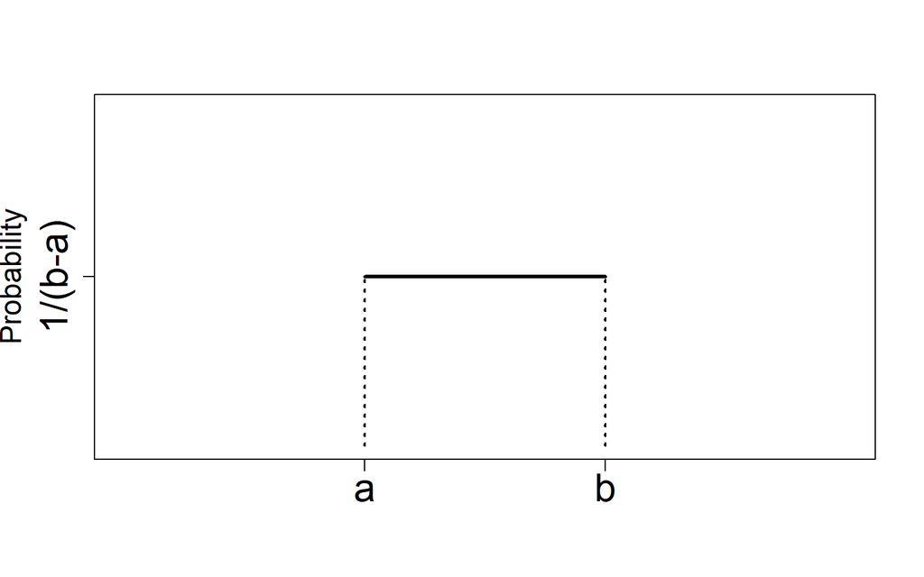

```r
plot(c(0.5,0.5),type='l',pch=19,lwd=3,xlim=c(0,3),
ylim=c(0,1),xaxt='n',yaxt='n',xlab="",
ylab="Probability",cex.lab=1.5,cex.axis=1.5)
axis(1,at=c(1,2),labels=c('a','b'),cex.axis=2)
axis(2,at=0.5,labels="1/(b-a)",cex.axis=2)
lines(c(1,1),c(0,0.5),lty=3,lwd=2)
lines(c(2,2),c(0,0.5),lty=3,lwd=2)
```

probability distribution shown above, the probability to observe a value within a range of width w is simply proportional to w, since the distribution function is constant. In the case of general probability distribution $f(x)$, the probability to observe a value of random variable in a small (infinitesimal) interval $[x,x+dx]$ is equal to $f(x)dx$ and for any finite interval $[a,b]$ the probability to observe a value in that interval is $\int_{a}^{b}f\left ( x \right )dx$ . Since the distribution has to be multiplied by (and integrated with) the interval length, in continuous case the probability distribution is often referred to as probability density.

We have already encountered another distribution function, a Gaussian distribution. It is very important and is worth listing here again as well:

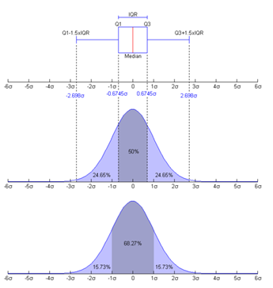

$$f\left ( x \right ) =
\frac{1}{\sqrt{2\pi \sigma ^{2}}}e^{-\frac{\left ( x-\mu \right
)^{2}}{2\sigma ^{2}}}$$

- 50% of the data are within $[ \mu - 0.67\sigma , \mu + 0.67\sigma ]$ interval
- 68.3% - within $1\sigma$
- 95.4% - within $2\sigma$
- 99% - within $2.58\sigma$
- 99.7% - within $3\sigma$

The density function shown above gives the probability (strictly speaking probability density) to observe a value x of a Gaussian random variable X with mean μ and standard deviation σ. As the plots demonstrate, it is much more likely to observe a value at or near μ, and the probability to observe values far away from the mean decreases fast (but never becomes zero, so it is extremely unlikely but still possible to accidentally observe a value very remote from the center of the distribution!).

Note that the distribution function must always be normalized: since the probability to observe one of all possible outcomes is 1, the distribution function across all possible outcomes should sum up to 1, or in continuous case, $f\left ( x \right ) = \int_{-\infty }^{\infty} f\left ( y \right )dy = 1$.

## 3.1 Cumulative Distribution Function

Another function closely related to the probability distribution is the cumulative distribution function, or CDF. While the probability distribution (or probability density) $f(x)$ tells us about the chances to observe a value $x$ of the random variable, the CDF $F(x)$ is defined as a probability to observe any value y<x. It thus follows that for any probability distribution its relation to the CDF is as follows: $f\left ( x \right ) = \int_{-\infty }^{\infty} f\left ( y \right )dy$. (in plain English: a “sum” of the probabilities to observe all values below $x$). The figure below shows a few examples of Gaussian distributions with different means and variances and the corresponding CDFs (shown in the same color):

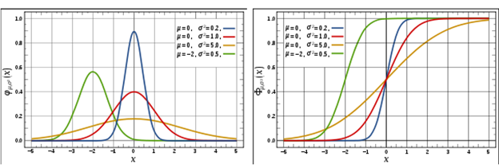

# 4 Digression: Combinatorics

When dealing with sampling from discrete sets of examples (discrete populations), we often times find ourselves asking a question: how many different selections we could make. Skip this section if you know the answer. Otherwise, let us consider a following example: we have 81 objects (e.g. marbles of different colors or balls with numbers written on them). We want to randomly select 20 objects (e.g. by placing all our objects into a jar and pulling out 20, one by one, without looking and without placing the objects we have drawn back into the jar – this is called sampling without replacement).

[figure not shown]

Obviously, we have 81 different possibilities to retrieve the first object (i.e. we can draw any of the 81 objects in the jar with equal probability). For each of those 81 possibilities, when we draw the second object there are 80 remaining in the jar and we can draw any of those. Hence, we have $81*80$ different ways to draw two objects. Similarly, for each of those $81*80$ variants, when we reach for the third object we draw any one of the remaining 79, hence there are $81*80*79$ different possibilities to draw three objects and so forth. The total number of possibilities to draw 20 objects out of 81 thus seems to be $81*(81-1)*(81-2)*...*(81-19)$.

There is one caveat: in the way we counted possibilities, the order in which we have drawn the objects matters. We could first draw object ‘A’, then ‘B’ – one variant. Or we could draw first ‘B’, then ‘A’ – we counted that as a different variant. If we are concerned only with the identities of the objects we have drawn, but not with the particular order, we want to count all variants that differ only by the order of the drawn objects as one. How many different orderings of 20 objects are there? Using the same logic, let us count how many different possibilities there are to draw 20 objects out of 20 (by drawing them all we simply generate a random reordering of our sample, so we are just counting permutations now). Again, there are 20 possibilities to draw first object, for each of those possibilities there are 19 possibilities to draw the second object etc. So at the end, there are $20*19*...*1=20$! different possible permutations of the same set of 20 objects.

Thus the final answer to our question (how many distinct selections of 20 objects out of 81 we can make, regardless of the particular order of the selected objects) is: $81*80*...(81-19)/20$!. It is easy to see that in general case (how many ways there are to choose k objects out of n, without replacement and regardless of the order), the answer is $n\left ( n-1 \right )\cdot ...\cdot \left ( n-k+1 \right )/k$!

Not surprisingly, R provides a function called `choose(n,k)` that computes this expression.

# 5 Binomial Distribution

Now that we understand how many different subsets of a fixed size we can choose from a given set, we can introduce another very important distribution: Binomial distribution.

Let us assume that we perform a series of n Bernoulli trials, with probability of success of each trial equal to $p$ (plain English: we have a coin, not necessarily fair, with probability $p$ to toss a head, and we flip such a coin n times). What is the probability that we will observe head in exactly $k$ out of $n$ tosses?

First, let us note that each coin toss is independent: regardless of the previous history, whether we have observed half heads and half tails or have seen only tails so far, the probability to observe a head on next toss is the same as it was on the first toss, p. Any possible realization of our experiment can be described as a sequence of n observations: e.g. $T,H,T,T,T,H,H,...,$ and since the tosses are independent, the probability of any realization with k heads is equal to $p^{k}\left ( 1-p \right )^{n-k}$. Stop for a second here and realize that any sequence of observations with exactly $k$ heads is equally probable, whether we observed k heads in a row followed by all tails or we have been observing $H,T,H,T,...$ Moreover, when $p=0.5$, so that $p=1-p$, any given sequence of heads and tails is equally probable: you are as likely to observe all tails as you are to observe $T,H,T,H,...$ or $n/2$ tails followed by $n/2$ heads.

But how many different realizations with exactly k heads exist? We have performed trials (tosses) $1,2,...,n$, and each realization is completely characterized by specifying in which tosses a head was observed (e.g. 5th, 7th, and 13th) – the rest are automatically tails. So the question becomes: how many different ways are there to select k numbers (trials) from the set $1,2,...,n$. The answer is of course choose(n,k) as we have just seen.

In order to calculate the probability to observe exactly k heads, we need to sum up probabilities of all realizations with exactly $k$ heads. Since those probabilities are the same, and the total number of such different realizations is `choose(n,k)` (denoted in mathematical

formulas as either $\binom{n}{k}$ or $C_{n}^{k}$), the final answer is

$$P\left ( k \right ) =
\binom{n}{k}p^{k}\left ( 1-p \right )^{n-k}=\frac{n!}{k!\left ( n-k
\right )!}p^{k}\left ( 1-p \right )^{n-k}$$

This is Binomial distribution. As we will see shortly, R has functions for binomial (and other) distributions, but let us plot the distribution function of Binomial distribution manually, just for practice. We are going to consider n=15 trials and success probability p=0.2.

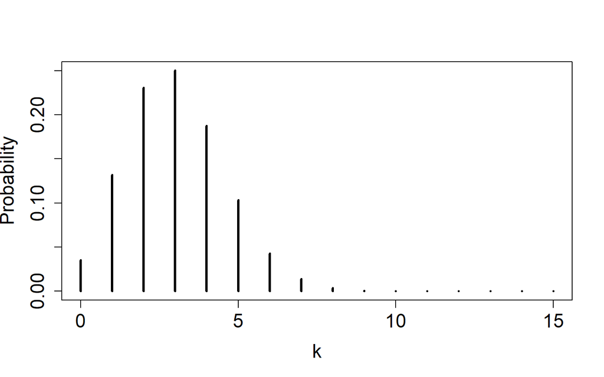

```r
k<-0:15 # we can observe anywhere from 0 to 15 heads in 15 trials
plot(k,choose(15,k)*0.2^k*
0.8^(15-k),type='h',
lwd=3,ylab='Probability',cex.axis=1.5,cex.lab=1.5)
```

Please note the important difference: Bernoulli trial is a single dichotomic random process (e.g. tossing a coin). Tossing a coin multiple times is thus performing multiple trials (measurements) of a Bernoulli random variable. If we consider n Bernoulli trials as a single experiment, we have a different random process and we characterize it differently (e.g. by the total number of heads, out of n tosses). This latter experiment is a Binomial, and repeating a binomial trial (e.g. measuring the binomial random variable again) means repeating all n tosses over again, counting how many heads we observed this time, etc.

In more formal terms (this will be useful later!), we can define a Bernoulli random variable X as having possible values (outcomes) of 0 (for tails) and 1 (for heads) instead of $H/T$. Then if we have n such independent trials $X_1,X_2,...,X_n$ , then we can define new random variable

$$Z=X_1 + X_2 + ... + X_n$$
.

Since random variables are processes, not fixed values, the expression above (this is also a standard notation!) should be understood as: Z is a random variable, and for each realization of (independent) processes $X_1,...,X_n$, the corresponding realization of $Z$ is defined as the sum of those realizations (observations). It is easily seen that if we have realization in which exactly $k$ of our Bernoulli random variables take value 1 (head), then this defines realization of $Z$ with the value $k$, so $Z$ is indeed a binomial random process. We say in this case that binomial random variable $Z$ is a sum of independent, identically distributed (i.i.d.) Bernoulli random variables $X_i$.

# 6 Distribution Functions in R

Probability distributions and distribution generating (sampling) functions (see below) are indispensable for numerical simulations, and R provides a number of standard distributions ready for use. See ‘?Distributions’ for the list of available options. The provided functions follow the same naming convention: functions with names starting with ‘d’ implement probability distribution itself, for instance `dnorm()` for normal (Gaussian) distribution, `dunif()`for uniform distribution, `dbinom()` for binomial, etc. In the example below we plot probability density of the normal distribution using the standard function `dnorm()`.

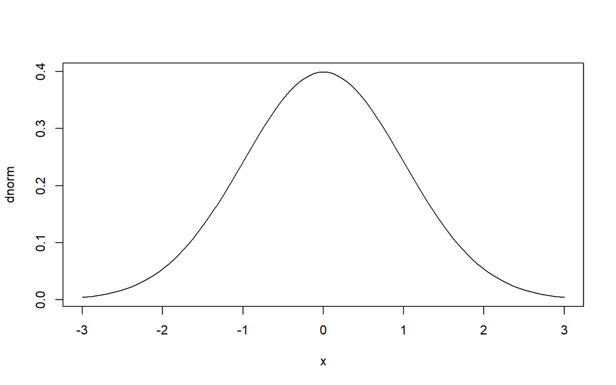

```r
plot(dnorm,from=-3,to=3)
```

Note the completely new variant of the plot command in the example above. What happens here is that R actually provides some rudimentary OOP capabilities, in particular function overloading: same function may have different versions/behave differently depending on what `class()` of object it is applied to. We are not learning how to use these capabilities/write code into them in this course, but they are worth at least being aware of. Function `plot()` has an overloaded version `plot.function()` which is automatically called when you try applying `plot()` not to a vector (as we did so far) but to a function object (and this is by the way what the authors of documentations pages mean when they mention that a particular function has “overloaded” methods for different objects). The overloaded version of plot() has from=, to= arguments (default plot() function that works on vectors does not!), so it can automatically plot the specified function in the specified range of x-coordinate (try `plot(sin,from=-5,to=5)`). If we were trying to achieve the same goal by using the standard, default `plot()`, we would need to first create an x-coordinate vector, e.g. `x=seq(-5,5,by=0.01)`, and then use default (scatterplot) version to generate vector-vs-vector x-y plot: `plot(x,sin(x))`.

`d{distribution}` is only one quarter of this naming convention; R provides four related functions for every standard distribution, all sharing the same one-letter prefix pattern:

- `d{distribution}`: the density (continuous) or probability mass (discrete) function: given a value $x$, returns the probability, or probability density, of observing exactly that value. This is `dnorm()`, `dbinom()`, etc.
- `p{distribution}`: the cumulative distribution function (CDF) introduced above: given a value $x$, returns $P(X \leq x)$, the probability of observing a value at or below $x$. This is `pnorm()`, `pbinom()`, etc.; passing `lower.tail = FALSE` flips it to $P(X > x)$ instead.
- `q{distribution}`: the quantile function, the inverse of the CDF: given a probability, returns the value $x$ such that $P(X \leq x)$ equals that probability. Reach for this when a question runs backwards from the CDF: not “what is the probability of at most this value,” but “what value corresponds to this probability.”
- `r{distribution}`: the sampling function discussed just below: draws random realizations from the distribution.

Continuing the standard normal example above:

```r
pnorm(1.96)     # P(X <= 1.96) for the standard normal: the CDF value
```

```
## [1] 0.9750021
```

```r
1 - pnorm(1.96) # P(X > 1.96), the upper tail
```

```
## [1] 0.0249979
```

```r
qnorm(0.975)    # the value x such that P(X <= x) = 0.975 -- the inverse of the line above
```

```
## [1] 1.959964
```

Notice that `qnorm(pnorm(1.96))` returns 1.96 again (up to floating-point rounding): `q{distribution}` and `p{distribution}` are inverses of one another. The same four functions exist for the binomial distribution from the previous section, `dbinom()`, `pbinom()`, `qbinom()`, `rbinom()`, and behave the same way, just for a discrete rather than continuous variable: `pbinom(k, size = n, prob = p)` gives $P(X \leq k)$ for a binomial with $n$ trials and success probability $p$, and `qbinom()` inverts that to find the $k$ corresponding to a given cumulative probability.

You probably will not be using `d{distribution}` functions too often in your analysis (maybe to compare empirical distribution against the standard one). What is much more useful for us is a sampling function. Imagine that you want to perform a numerical experiment (and you should get used to this image because we are going to perform lots of those experiments in the coming weeks). You believe that some quantity of interest (for instance, blood pressure) has Gaussian distribution in the population, with some mean and variance. You want to simulate how your results would look if you were to randomly sample just 20 people from that population and measure their blood pressure. This is where the sampling functions (in R their names by convention start with ‘r’: `rnorm()`, `runif()`, `rbinom()`, etc) come to the rescue. If, for instance, you execute `rnorm(20)` command, R will return a vector of 20 values (realizations) of random normal (Gaussian) variable with mean 0 and variance 1 (defaults, can be changed, see docs). These values are drawn according to the underlying distribution: you are more likely to receive values close to the mean and less likely to receive values far from it, just like Gaussian distribution prescribes. However, due to the small sample size you may experience sampling fluctuations, as it is demonstrated below:

```r
set.seed(1)    # optional: reproducible “random numbers”
y <- rnorm(20) # sample at random 20 values from Gaussian
mean(y)        # ooops, mean is far from 0! Let’s try again:
```

```
## [1] 0.1905239
```

```r
y <- rnorm(20); mean(y); y <- rnorm(20); mean(y)
```

```
## [1] -0.006471519
```

```
## [1] 0.1387968
```

Note how we sampled 20 values from the Gaussian distribution three times in a row and every time obtained different values of the average value of the retrieved sample. This is the randomness introduced by random sampling as we discussed earlier in this Note. The underlying distribution only prescribes higher probability to sample values at or near its center, but with some lower but finite probability we may get too many values far from the center, or values that are not quite symmetric around the center, etc. Note also the `set.seed()` command in the snippet above. “Random” sampling in R (and any other computer language) is generated by using a pseudo-random number generator: there are no objectively random physical processes on-board that can be harvested for true random number generation. Pseudo-random number generators are usually initialized with current system clock value in milliseconds and this guarantees (with overwhelming probability) that no two re-runs of the generator will return the same sequence of numbers. Sometimes, however, we do want to rerun the code exactly, even when it uses “random” numbers. In this case, you can manually set the seed to an arbitrary fixed value, and as long as you re-initialize to that same value, your code will generate exactly the same results next time, including the parts dependent on “random” numbers.

Finally, let us plot an empirical distribution of the data, i.e. the distribution that we observe in the sample that is available to us. Note that histogram actually draws just that: the empirical distribution, albeit in somewhat coarse-grained representation. Indeed, the (relative) count of values falling into any particular bin in a histogram is nothing but the probability to observe a value in that particular range (as computed from available data).

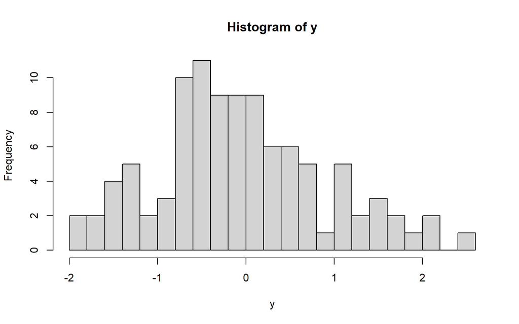

```r
y <- rnorm(100); hist(y,breaks=20)
```

Note how the empirical distribution is still visually skewed and distorted, even though we tried to sample 100 values this time: while we sampled 100 values randomly from a Gaussian distribution, the distribution of the (finite) sample we obtained does not quite look normal!

# 7 Summary

Random variable is a process that can take different values (realizations) upon subsequent measurements; these values cannot be predicted, but are random and it is only possible to study and compare probabilities of different values; the function that associates probabilities with each value the random variable realization can take is called distribution function or probability density. Bernoulli trial is a simple, discrete process with just two outcomes. Binomial random variable is (formally) a sum of Bernoulli variables. Binomial trial (i.e. what binomial variable represents) is an experiment in which Bernoulli trial is performed n times and the number of successes is counted. R provides a number of standard distributions: both in the form of distribution functions and CDF functions, and in the form of random samplers capable of creating a sample following the underlying distribution

# 8 Population Statistics vs Sample Statistics

It has been already implied a few times in our Notes that there is an important conceptual difference between the population statistics and sample statistics. As this notion should have settled down a little by now, it is time to give it a more formal treatment.

“Population statistics” is just a name for the descriptive characterization of the whole population (with respect to particular quantity we are interested in). Note that this can be just an idealization since we usually do not have measurements for everyone in a population. The important point is that the underlying distribution of the quantity of interest, $f(x)$, always exists. We may not know its parameters (where it is centered or how much spread it has) or even its shape, but this is exactly why we perform the measurements.

When we perform a finite number of measurements we are sampling randomly from the underlying population. Note that the word “population” itself can be somewhat misleading: it has direct meaning only if we, for instance, select a finite number of study participants from the large population and measure their cholesterol levels or poll their party affiliations. But if our measuring apparatus is subject to noise and we perform five measurements on each subject in order to overcome that noise, it is better to say that our repeated measurements are sampled from the underlying noise distribution, not a “population” of any sort. Hence, while we will be sometimes using these terms interchangeably (e.g. when we indeed sample from a human population), the universally applicable concept is that of sampling from underlying distribution and trying to determine its parameters or other interesting properties, whether that underlying distribution describes patients or some random measurement error.

For an underlying distribution $f(x)$ we can define different parameters, such as mean (or expected value):

**(1)**

$$E[x] = \int_{-\infty }^{\infty }xf(x) =
\mu$$

or variance (mean squared deviation from the mean):

**(2)**

$$Var(x)=E[(x-\mu )^{2}] = \int (x-\mu
)^{2} f(x)dx=\sigma ^{2}$$

It is worth reiterating once again that these are characteristics of the underlying distribution: fixed (but possibly unknown) values, not random variables! In some cases we might be unsure even about the shape of the underlying distribution, which can make the problem more difficult. In many other cases we know from general considerations the shape of the underlying distribution or at least expect it to be well approximated by one of the known distributions. Gaussian distribution represents one such important example – we can reasonably expect many unknown distributions to be sufficiently close to it (we will discuss reasons for that later):

**(3)**

$$f(x) = \frac{1}{\sqrt{2\pi \sigma
^{2}}}e^{-\frac{(x-\mu )^{2}}{2\sigma ^{2}}}$$

We use the same notations μ, σ both for the mean and variance in the definitions above and for the parameters of the Gaussian distribution for a reason: for Gaussian distribution its parameters μ, σ are indeed precisely the expectation and variance.

When we take a single measurement, we are randomly choosing realization x according to the underlying distribution $f(x)$ (naturally, the probability to randomly select and measure a value very common in the population is higher than the probability to select a rare value). So our measurement process can be formally described as a random variable $X$ distributed as $f(x)$ (where $f(x)$ might be apriori unknown and subject to estimation from the measurements). Let us suppose now that we perform n measurements; this process can be represented by an ensemble of n independent identically distributed (i.i.d.) random variables $X_1,X_2,...,X_n$ (each of $n$ measurements is independent from the others and each is distributed according to $f(x)$). When we perform such panel of measurements once, we end up with a realization (or sample) $x_1,x_2,...,x_n$. This is the only information available and using that information we need to make inference about the underlying distribution.

How do we make this connection from (randomly selected) samples to the underlying distribution(s) is the topic of our discussion for coming weeks. As the simplest illustration, we can for now consider the sample average, or sample mean:

**(4)**

$$\bar{x} = \frac{1}{n}\cdot
\sum_{i=1}^{n}x_i$$

this is what R function `mean()` computes given a sample (vector of measured values). How does sample mean refer to the actual, true mean of the underlying distribution (the expectation value defined above)? While it perfectly agrees with our intuition that by taking a random sample from an unknown underlying distribution and computing the mean of that sample, as in (4), we somehow approximate the true mean (expected value) μ of that distribution (1), you have to appreciate the fact that Equation (4) does not look much like Equation (1). It is not completely trivial (not too hard either, but beyond our scope) to rigorously prove that Eq. (4) indeed approximates (1) and actually converges to the expected value of the underlying distribution with increasing sample size. This is one of the central facts of probability theory, known as “law of large numbers”. A quantity computed from available data (a sample) with the purpose of approximating some parameter of the (unknown) underlying distribution is known as an estimator. Thus, we can say that sample average in Equation (4) provides an estimator for the true underlying population mean μ.

Important property of the sample average (and any other sample statistic for that matter) is that it is a random variable in itself. Indeed, the average value in Eq. (4) depends on the particular realization $x_1,...,x_n$ we happened to measure. If we repeat the whole measurement procedure (i.e. randomly select new n subjects and measure them again, or rerun our measurement apparatus n times against the same noisy signal), we will obtain a different realization (sample) and its mean will be also slightly different (we already observed this from direct simulation using `rnorm()` in Part 1 of this week’s notes). Hence it is a meaningful question how the sample mean (as a random variable) is distributed around the true underlying expected value it approximates. Can we have a reasonable and quantifiable expectation for the probability for our estimator to lie within some predefined range around $\mu$? We will answer this question a little later, but for now make sure you appreciate it!

Another useful quantity we may want to estimate from our sample is the variance (2). Interestingly enough, the quantity simply defined as average squared deviation from the mean (also determined from the same data),

**(5)**

$$S_{n}^{2} = \frac{1}{n}\sum (x_{i} -
\bar{x})^{2}$$

where x is defined in (4), does approximate population variance (2), and thus is an estimator, but it is not an optimal one. The quantity defined in (5) is a variance of the sample considered as a whole population, and is known as “biased estimator of variance”; the source of the bias is that the sample itself (its mean in particular) may fluctuate away from the true underlying distribution due to random sampling. The unbiased sample variance,

**(6)**
$$S_{n-1}^{2} =
\frac{1}{n-1}\sum (x_{i} - \bar{x})^{2}$$

can be shown to provide a better approximation to the variance of the underlying distribution the sample was drawn from. It is easy to see that the difference between the two estimators becomes negligible as n increases, but since in practice we often deal with relatively small samples, it is important to remember that (6) provides a better approximation. You will be asked to demonstrate this fact numerically using brute force simulation in your homework assignment. To add to the confusion, the variance estimate is often denoted in the literature simply as s2, so it is left to the reader to figure out which estimator is actually used (but usually it is (6)).

The last observation to derive from this discussion is that it is possible to have multiple estimators (i.e. expressions involving measured values xi from our sample) for the same underlying quantity. Some estimators provide better approximations, some are less biased, some are more robust with respect to excessive noise in the data, and some others may be easier to compute.